# Plany złożone

Krzysztof Basiński

4/11/2018

> **UWAGA!** Jeśli ktoś z Was znalazł by przez przypadek jakiś błąd w tym dokumencie, niech da znać mailowo na k.basinski@gumed.edu.pl
- Plan złożony jest wtedy, kiedy badamy wpływ więcej niż jednej zmiennej niezależnej (czynnika)
- Na plan złożony składać się mogą warunki w planie grup niezależnych lub powtarzane pomiary (lub jedno i drugie)
- Plany złożone pozwalają na określenie **efektu głównego** każdego czynnika
- Pozwalają też na określenie efektu kilku czynników lub wszystkich czynników łącznie – **efekt interakcji**

## Efekty proste, główne i interakcja

- Efekt prosty to różnica w zmiennej zależnej pomiędzy poziomami jednego z czynników
- Efekt główny to wpływ jednego z czynników niezależnie od drugiego
- Interakcja jest wtedy, kiedy oba czynniki razem wpływają na zmienną zależną

W planie 2x2 mamy (możliwe):

- cztery efekty proste
- dwa efekty główne
- jeden efekt interakcji

## Przykłady

- Eksperyment w planie 2x2
- Badamy wpływ poziomu pobudzenia emocjonalnego i trudności zadania na pamięć.
- Zmienna zależna: pamięć (wynik testu pamięci)
- Czynniki: poziom pobudzenia x trudność zadania

#### Przykład 1

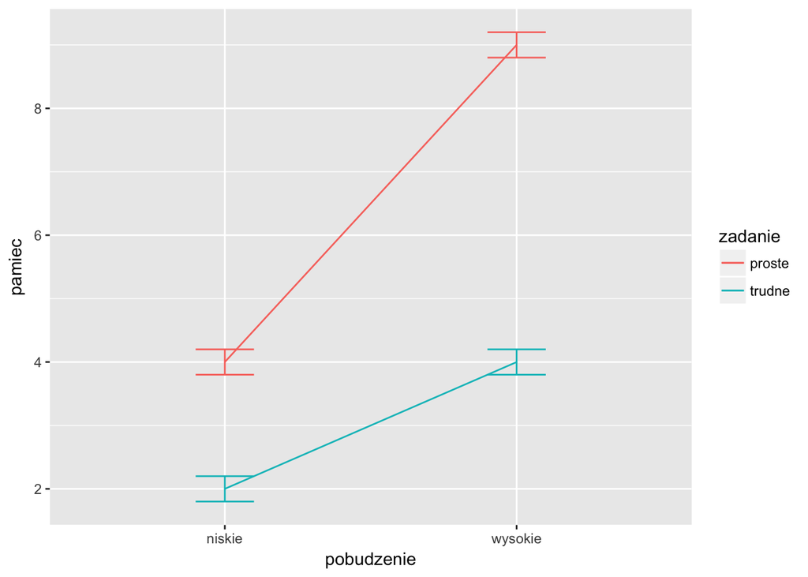

Efekty proste:

- Efekt prosty trudności zadania przy niskim pobudzeniu
- Efekt prosty trudności zadania przy wysokim pobudzeniu
- Efekt prosty pobudzenia przy trudnym zadaniu
- Efekt prosty pobudzenia przy prostym zadaniu

Efekty główne:

- Efekt główny trudności zdania
- Efekt głowny pobudzenia

Efekt interakcji:

- Istotny efekt interakcji

#### Przykład 2

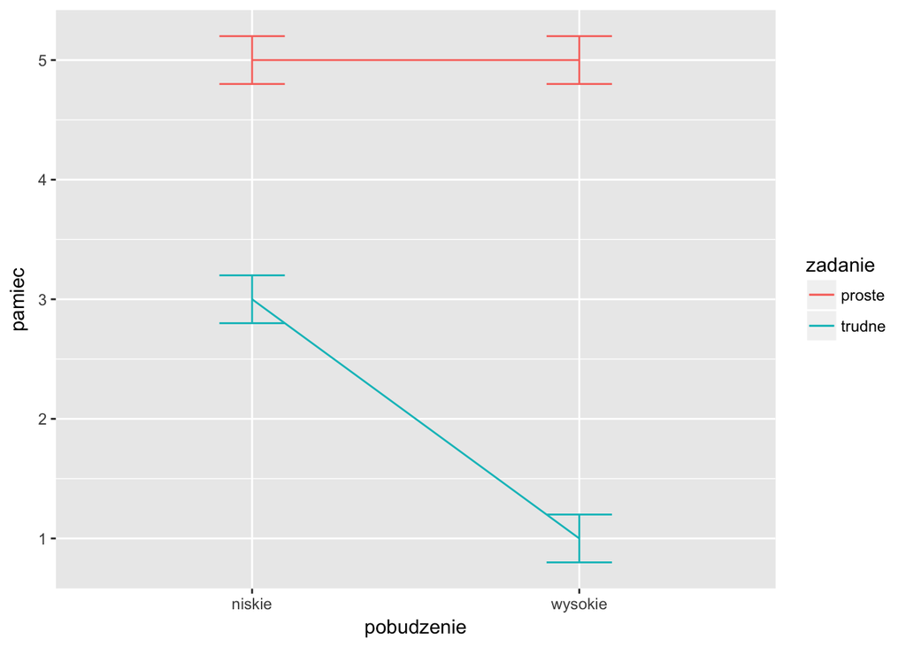

Efekty proste:

- **Brak efektu prostego** pobudzenia w warunku prostego zadania
- Efekt prosty pobudzenia w warunku trudnego zadania
- Efekt prosty trudności zadania w warunku niskiego pobudzenia
- Efekt prosty trudności zadania w warunku wysokiego pobudzenia

Efekty główne:

- Efekt główny pobudzenia
- Efekt głowny trudności zadania

Efekt interakcji:

- Istotny efekt interakcji

#### Przykład 3

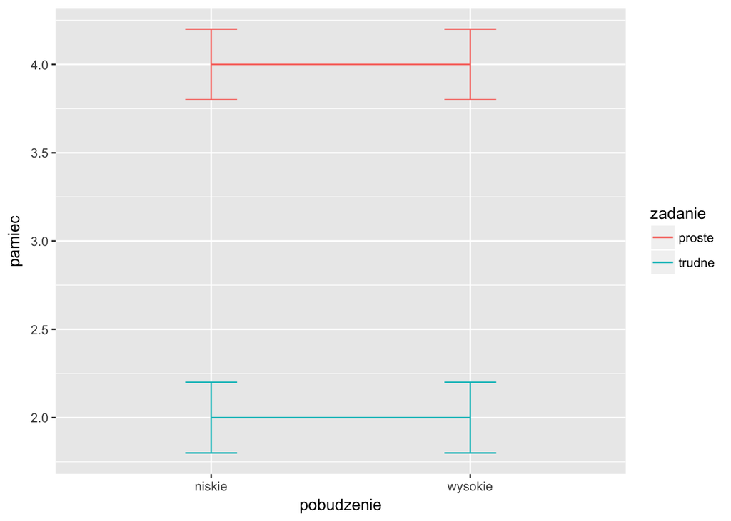

Efekty proste:

- **Brak efektu prostego** pobudzenia w warunku prostego zadania
- **Brak efektu prostego** pobudzenia w warunku trudnego zadania
- Efekt prosty trudności zadania w warunku niskiego pobudzenia
- Efekt prosty trudności zadania w warunku wysokiego pobudzenia

Efekty główne:

- **Brak efektu głównego** pobudzenia
- Efekt głowny trudności zadania

Efekt interakcji:

- **Brak efektu interakcji**

#### Przykład 4

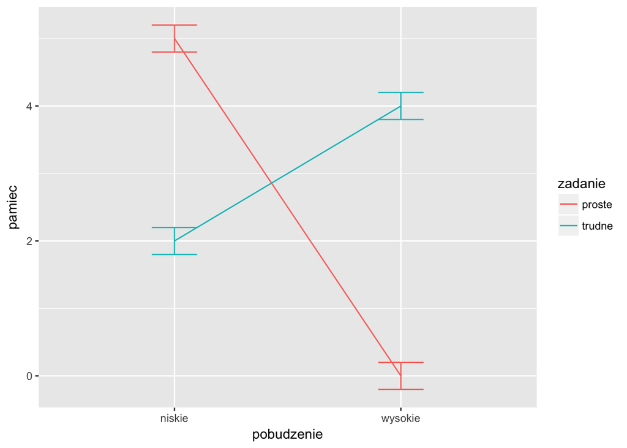

Efekty proste:

- Efekt prosty pobudzenia w warunku prostego zadania
- Efekt prosty pobudzenia w warunku trudnego zadania
- Efekt prosty trudności zadania w warunku niskiego pobudzenia
- Efekt prosty trudności zadania w warunku wysokiego pobudzenia

Efekty główne:

- Efekt główny pobudzenia
- Efekt głowny trudności zadania (niewielka różnica, trzeba by przetestować!)

Efekt interakcji:

- Istotny efekt interakcji

#### Przykład 5

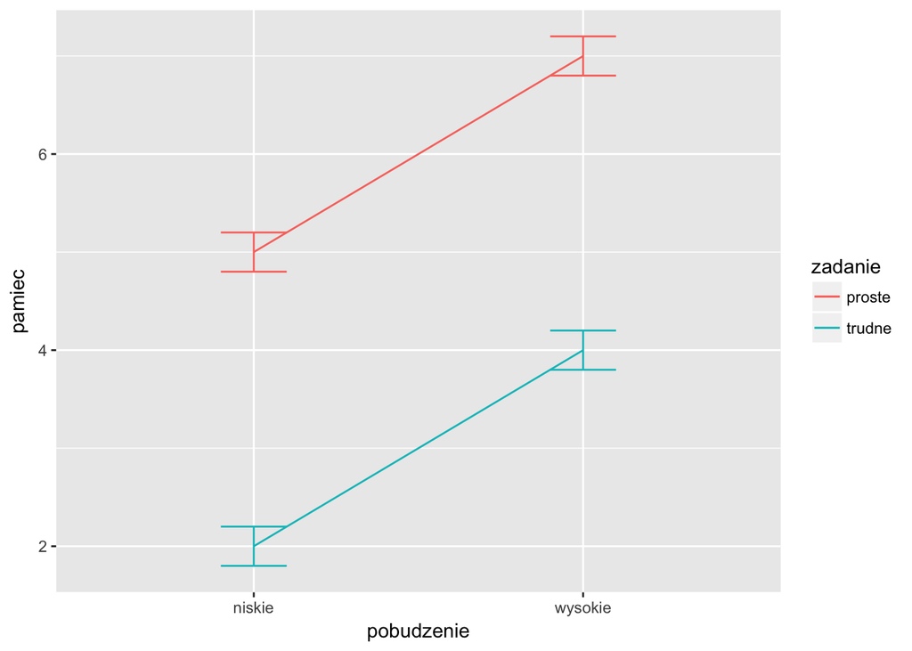

Efekty proste:

- Efekt prosty pobudzenia w warunku prostego zadania
- Efekt prosty pobudzenia w warunku trudnego zadania
- Efekt prosty trudności zadania w warunku niskiego pobudzenia
- Efekt prosty trudności zadania w warunku wysokiego pobudzenia

Efekty główne:

- Efekt główny pobudzenia
- Efekt głowny trudności zadania

Efekt interakcji:

- **Brak efektu interakcji**

#### Przykład 6 (*)

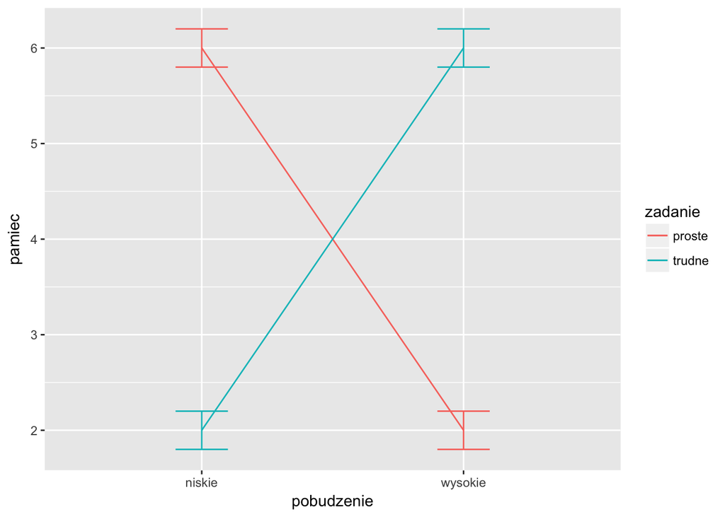

Ten przykład jest szczególny. Tu **mamy istotną statystycznie interakcję**! Można to interpretować tak, że pomimo iż zmiana (∆) jest taka sama dla obu czynników, ma ona odwrotny charakter. Stąd mamy istotną statystycznie interakcję.

### Przykład planu 2 x 3 (*)

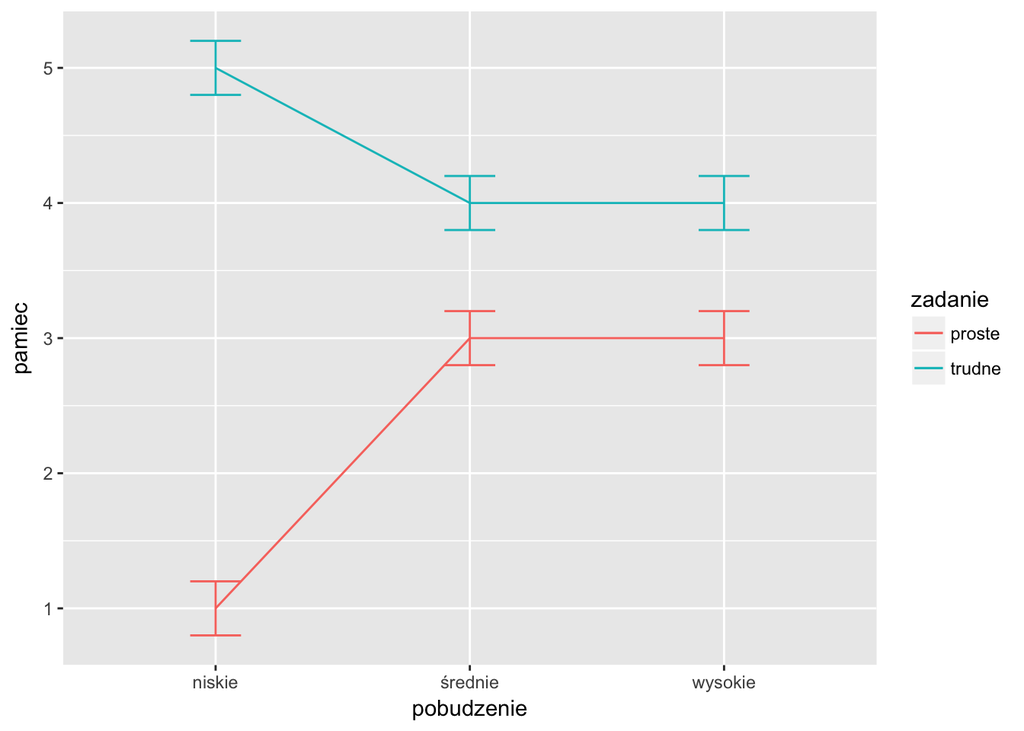